# ugr.multivariante.correspondencias

franmarq@gmail.com

2022-11-22

Para este ejecicio vamos a utilizar los datos ‘Burdeaux’ que son las opiniones de 200 jueces en una cata a ciegas de cinco tipos diferentes de vinos tinto de la zona de Burdeos, en el suroeste de Francia. Esta data viene incluida en el paquete ‘Ade4’.

```r
library("ade4")
library("factoextra")
data(bordeaux)
head(bordeaux)
```

```
##                    excellent good mediocre boring
## Cru_Bourgeois             45  126       24      5
## Grand_Cru_classe          87   93       19      1
## Vin_de_table               0    0       52    148
## Bordeaux_d_origine        36   68       74     22
## Vin_de_marque              0   30      111     59
```

Tal como fue solicitado, vemos que la variable opinión cuenta con 4 categorias y la variable marca cuenta con 5 marcas de vinos distintos.

```r
chisq.test(bordeaux)
```

```
##
##  Pearson's Chi-squared test
##
## data:  bordeaux
## X-squared = 731.85, df = 12, p-value < 2.2e-16
```

El resultado del test chi-cuadrado nos sugiere rechazar la hipótesis de independencia de las variables (p<0.05) por lo que es válido aplicar un análisis de correspondencias para estudar su posible asociación

Aplicamos ahora el análisis de correspondencias

```r
db <- dudi.coa(bordeaux, scan = FALSE)
db
```

```
## Duality diagramm
## class: coa dudi
## $call: dudi.coa(df = bordeaux, scannf = FALSE)
##
## $nf: 2 axis-components saved
## $rank: 3
## eigen values: 0.5906 0.1102 0.03109
##   vector length mode    content
## 1 $cw    4      numeric column weights
## 2 $lw    5      numeric row weights
## 3 $eig   3      numeric eigen values
##
##   data.frame nrow ncol content
## 1 $tab       5    4    modified array
## 2 $li        5    2    row coordinates
## 3 $l1        5    2    row normed scores
## 4 $co        4    2    column coordinates
## 5 $c1        4    2    column normed scores
## other elements: N
```

El resultadio nos muestran valores para posible tres factores a considerar, el resultado de los valoires de inercia en los tres casos (eigen values): 0.5906 0.1102 0.03109, nos inidca que el primer eje tiene significativamente más poder clasificatorio que los otros dos. El tercero es muy bajo y puede ser descartado.

Graficamente estos resultados serían:

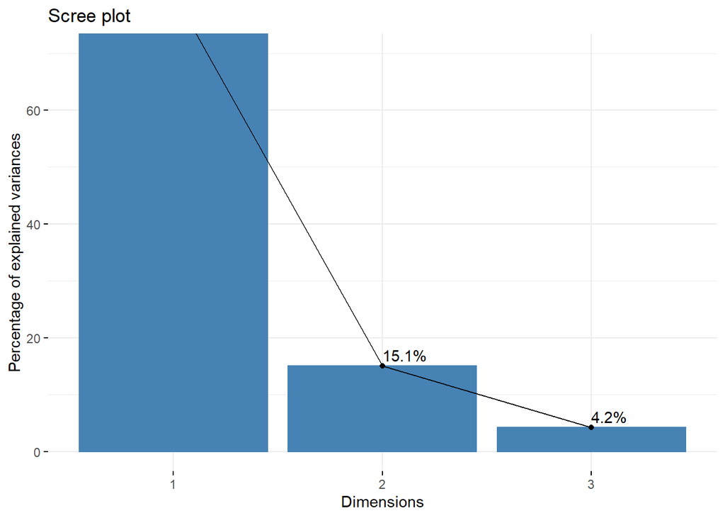

```r
fviz_screeplot(db, addlabels=TRUE,ylim=c(0,70))
```

Como se mencionó antes parece adecuado considerar sólo los dos primeros ejes para la explicación de la varianza total.

A continuación se obtienen los pesos de las filas y las columnas:

```r
db$lw
```

```
##      Cru_Bourgeois   Grand_Cru_classe       Vin_de_table Bordeaux_d_origine
##                0.2                0.2                0.2                0.2
##      Vin_de_marque
##                0.2
```

```r
db$cw
```

```
## excellent      good  mediocre    boring
##     0.168     0.317     0.280     0.235
```

De las marcas de vinos, todos parecen tener la misma influencia mientras que de las opiniones la de mayor influencia fue la de ‘Bueno’ (good)

Generamos ahora graficos que nos permitan describir como se relacionan las variables

En este primer grafico, En este las filas y las columnas se representan en el mismo espacio utilizando las coordenadas principales.

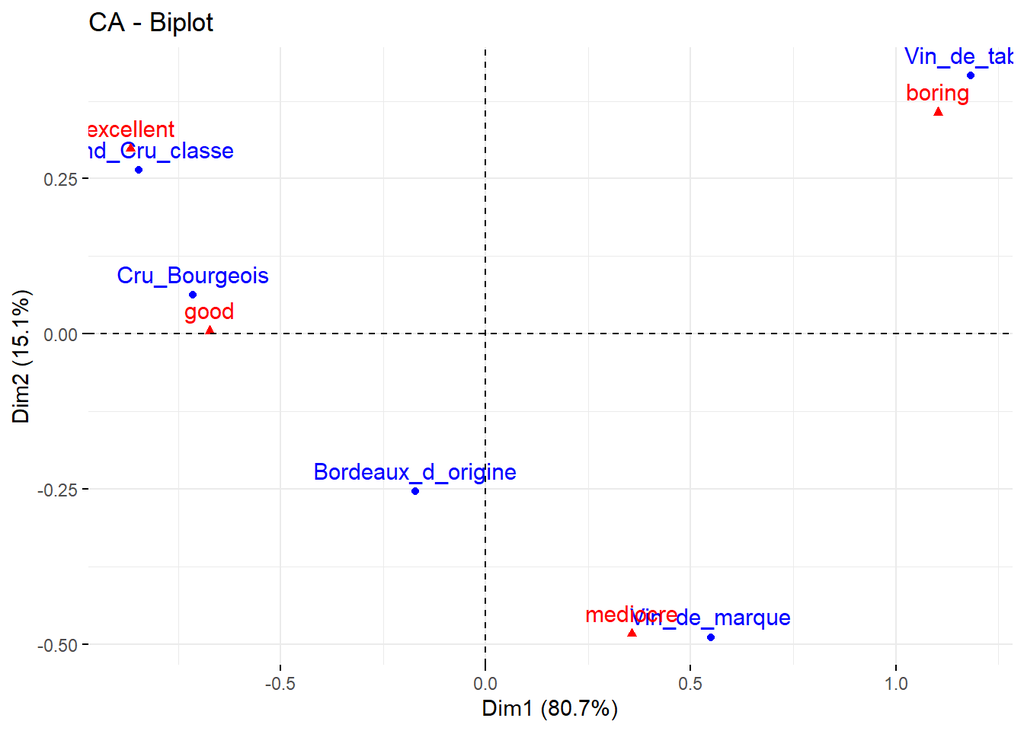

```r
fviz_ca_biplot(db)
```

Dado que la distancia entre los puntos, azules filas rojos columnas, es la que nos permite concluir sobre las similitudes en este grafico. vemos claramente como

Grand_Cru_classe se relaciona con la mayoria de las opiniones ‘excelente’. Cru_Bourgeois se relaciona con la mayoria de las opiniones ‘bueno’. Vin_de_table se relaciona con la mayoria de las opiniones ‘aburrido’. Vin_de_marque se relaciona con la mayoria de las opiniones ‘mediocre’.

Graficamos ahora los perfiles fila en el espacio de las columnas y El segundo gráfico representa los perfiles columna en el espacio de las filas

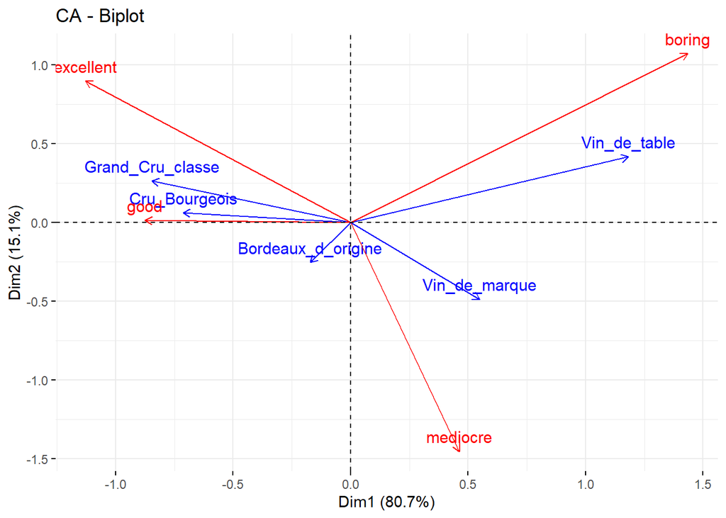

```r
fviz_ca_biplot(db, map ="rowprincipal", arrow = c(TRUE, TRUE))
```

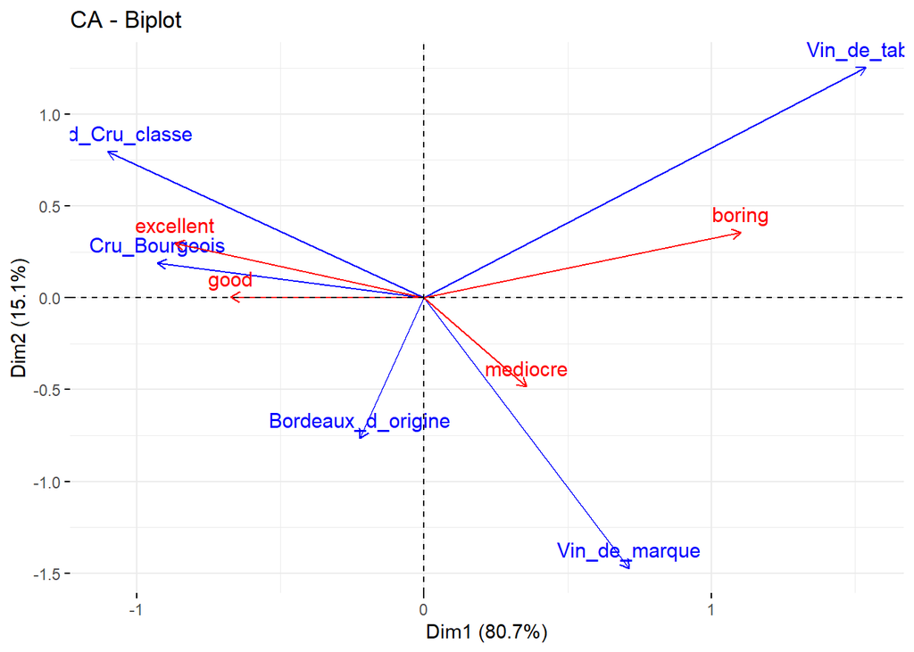

```r
fviz_ca_biplot(db, map ="colprincipal", arrow = c(TRUE, TRUE))
```

En estos grágicos, si el ángulo entre dos flechas es agudo, entonces existe una fuerte asociación entre la fila y la columna correspondientes. Deducimos entonces alta correlación entre:

Grand_Cru_classe y ‘excelente’. Cru_Bourgeois con ‘bueno’. Vin_de_table con ‘aburrido’. Vin_de_marque con ‘mediocre’.